# Predictions using the Weight Lifting Up Exercises Dataset

Owusu

June 9, 2016

```r
knitr::opts_chunk$set(echo = TRUE, warning=FALSE, message=FALSE, fig.width=10, fig.height=5)
options(width=120)

library(lattice)
library(ggplot2)
library(plyr)
library(randomForest)
```

## Introduction

Based on a dataset provide by HAR http://groupware.les.inf.puc-rio.br/har we will try to train a predictive model to predict what exercise was performed using a dataset with 159 features  
We’ll take the following steps:

- Process the data.
- Explore the data, especially focussing on the two paramaters we are interested in.
- Model selection, where we try different models to help us answer our questions.
- Model examination, to see wether our best model holds up to our standards.
- A Conclusion where we answer the questions based on the data.
- Predicting the classification of the model on test set

## Data processing

Load both datasets.

```r
pml.testing <- read.csv("~/Desktop/pml-testing.csv", header=TRUE)
pml.training <- read.csv("~/Desktop/pml-training.csv", header=TRUE)
```

## Exploratory data analysis

What we see is a lot of data with NA / empty values. Let’s remove those:

```r
dim(pml.training)
```

```
## [1] 19622   160
```

```r
maxNAPerc = 20
maxNACount <- nrow(pml.training) / 100 * maxNAPerc
removeColumns <- which(colSums(is.na(pml.training) | pml.training=="") > maxNACount)
train.cleaned1 <- pml.training[,-removeColumns]
test.cleaned1 <- pml.testing[,-removeColumns]
```

Also remove all time related data, since we won’t use those

```r
removeColumns <- grep("timestamp", names(train.cleaned1))
train.cleaned2 <- train.cleaned1[,-c(1, removeColumns )]
test.cleaned2 <- test.cleaned1[,-c(1, removeColumns )]
```

Then convert all factors to integers

```r
classeLevels <- levels(train.cleaned2$classe)
train.cleaned3 <- data.frame(data.matrix(train.cleaned2))
train.cleaned3$classe <- factor(train.cleaned3$classe, labels=classeLevels)
test.cleaned3 <- data.frame(data.matrix(test.cleaned2))
```

Finally set the dataset to be explored

```r
train.cleaned <- train.cleaned3
test.cleaned <- test.cleaned3
```

Since the yesy set provided is the ultimate validation set, we will split the current training in a test and train set to work with.

```r
set.seed(19791108)
library(caret)

classeIndex <- which(names(train.cleaned) == "classe")

partition <- createDataPartition(y=train.cleaned$classe, p=0.75, list=FALSE)
train.subSetTrain <- train.cleaned[partition, ]
train.subSetTest <- train.cleaned[-partition, ]
```

What are some fields that have high correlations with the classe?

```r
corr <- cor(train.subSetTrain[, -classeIndex], as.numeric(train.subSetTrain$classe))
fitCorr <- subset(as.data.frame(as.table(corr)), abs(Freq)>0.3)
fitCorr
```

```
##             Var1 Var2      Freq
## 27  magnet_arm_x    A 0.3023806
## 44 pitch_forearm    A 0.3475548
```

The fit correlations with classe are hardly above 0.3. Let’s check visually if there is indeed hard to use these 2 as possible simple linear predictors.

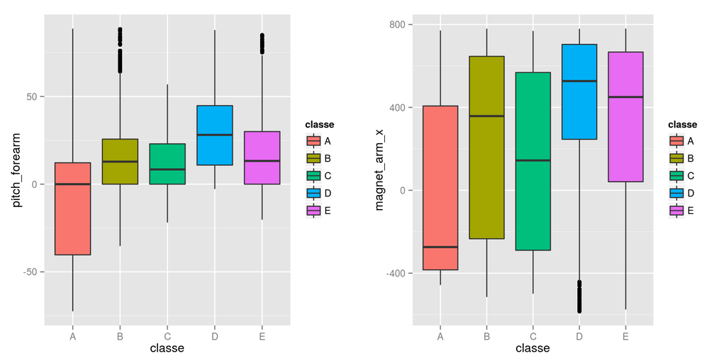

```r
library(Rmisc)

p1 <- ggplot(train.subSetTrain, aes(classe,pitch_forearm)) +
  geom_boxplot(aes(fill=classe))

p2 <- ggplot(train.subSetTrain, aes(classe, magnet_arm_x)) +
  geom_boxplot(aes(fill=classe))

multiplot(p1,p2,cols=2)
```

Clearly there is no hard seperation of classes possible using only these ‘highly’ correlated features. Let’s train some models to get closer to a way of predicting these classe’s.

## Model Selection

Let’s identify variables with high correlations amongst each other in our set, so we can possibly exclude them from the PCA or training.  
We will check afterwards if these modifications to the dataset make the model more accurate (and perhaps even faster)

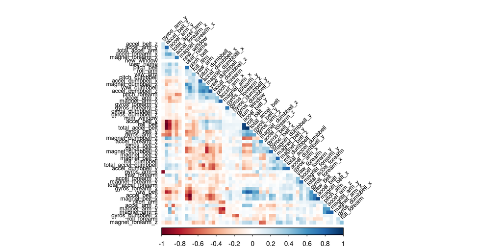

```r
library(corrplot)
correlationMatrix <- cor(train.subSetTrain[, -classeIndex])
highlyCorrelated <- findCorrelation(correlationMatrix, cutoff=0.9, exact=TRUE)
excludeColumns <- c(highlyCorrelated, classeIndex)
corrplot(correlationMatrix, method="color", type="lower", order="hclust", tl.cex=0.70, tl.col="black", tl.srt = 45, diag = FALSE)
```

We see that there are some features that are quite correlated with each other. We will have a model with these excluded. Also we’ll try and reduce the features by running PCA on all and the excluded subset of the features

```r
pcaPreProcess.all <- preProcess(train.subSetTrain[, -classeIndex], method = "pca", thresh = 0.99)
train.subSetTrain.pca.all <- predict(pcaPreProcess.all, train.subSetTrain[, -classeIndex])
train.subSetTest.pca.all <- predict(pcaPreProcess.all, train.subSetTest[, -classeIndex])
testing.pca.all <- predict(pcaPreProcess.all, test.cleaned[, -classeIndex])

pcaPreProcess.subset <- preProcess(train.subSetTrain[, -excludeColumns], method = "pca", thresh = 0.99)
training.subSetTrain.pca.subset <- predict(pcaPreProcess.subset, train.subSetTrain[, -excludeColumns])
training.subSetTest.pca.subset <- predict(pcaPreProcess.subset, train.subSetTest[, -excludeColumns])
testing.pca.subset <- predict(pcaPreProcess.subset, test.cleaned[, -classeIndex])
```